# Assignment 3: Model comparison

Marton Kovacs

In this lab assignment you are going to work with (simulated) data related to perioperative pain and its psychological and hormonal predictors. In the assignment you will assess the added benefit of including some psychological and hormonal predictors to the already established demographic predictors of pain.

In this assignment you will set up a hierarchical regression model to predict postoperative pain after wisdom tooth surgery.

# Research problem

The amount of pain experienced around and after surgeries are highly variable between and within individuals. In order to improve surgical pain management regimens we need to understand what influences pain around surgical procedures and predict the amount of pain an individual will experience.

Your first study in this area is related to assessing the influence of trait and state psychological measures on pain, and to see whether taking into account these variables can improve our understanding of postoperative pain.

# Procedures and measures

Use the data file called ‘assignment_3_dataset’, from the ‘data/’ folder.

You have collected data from 160 adults who were scheduled to undergo surgical extraction of the third mandibular molar (wisdom tooth surgery). Patients filled out a form in the waiting room before their surgery. The form contained questions about their sex, age, and weight, and psychological questionnaires assessing anxiety, pain catastrophizing, and mindfulness (see descriptions below). You also got blood samples and saliva samples from participants in the waiting room 5 minutes before their operations to determine the serum (a component of the blood) and salivary cortisol levels of participants. Participants were contacted 5 hours after the surgery to see how much pain they were experiencing. The **level of pain** at that moment was recorded using a numerical rating scale using a **scale of 0 to 10**, where 0 means “no pain” and 10 means “worst pain I can imagine”.

**The State Trait Anxiety Inventory:** T measures trait anxiety on a scale of 20 to 80, higher scores mean higher anxiety. Anxiety has been found in many studies to positively correlate with the level of pain experienced. This is **variable STAI_trait** in the dataset.

**The Pain Catastrophizing Scale** measures the extent of pain catastrophizing, which is characterized by a tendency to magnify the threat value of a pain stimulus and to feel helpless in the presence of pain, as well as by a relative inability to prevent or inhibit pain-related thoughts in anticipation of, during, or following a painful event. The total score on this scale ranges from 0 to 52, higher scores mean higher catastrophizing. Pain catastrophizing is one of the well-established predictors of clinical pain. This is **variable pain_cat** in the dataset.

**The Mindful Attention Awareness Scale (MAAS)** measures dispositional mindfulness, which may be described as a tendency to turn attention to present-moment experiences in an open, non-judgmental way. The MAAS total score ranges from 1 to 6 (an average of the item scores), with higher scores representing higher dispositional mindfulness. Trait mindfulness has been theorized to serve as a protective factor against pain, as the individual would be more objective about their pain experience and tend to associate less discomfort, despair, and hopelessness to the pain-related sensations. This is **variable mindfulness** in the dataset.

**Cortisol** is a stress hormone associated with acute and chronic stress. Cortisol levels are thought to be positively associated with pain experience. Cortisol can be **measured from both blood and the saliva**, although, serum cortisol is often regarded in medical research as more reliably related to stress (serum is a component of the blood plasma). These are **variables cortisol_serum**, and **cortisol_saliva** in the dataset.

# Research question

Previous studies and meta-analyses showed that age and sex are often predictors of pain (age is negatively associated with pain, while sex is a predictor more dependent on the type of the procedure). You would like to determine the extent to which taking into account psychological and hormonal variables aside from the already used demographic variables would improve our understanding of postoperative pain.

To answer this research question you will **need to compare two models** (with a hierarchical regression). The **simpler model** should contain **age and sex as predictors of pain**, while the **more complex model** should contain the **predictors: age, sex, STAI, pain catastrophizing, mindfulness, and cortisol measures**. Notice that the predictors used in the simpler model are a subset of the predictors used in more complex model. **You will have to do model comparison to assess whether substantial new information was gained about pain in the more complex model compared to the simpler model.**

# What to report

As usual, before you can interpret your model, you will need to run data and model diagnostics. First, check the variables included in the more complex model (age, sex, STAI, pain catastrophizing, mindfulness, and cortisol measures as predictors, and pain as an outcome) for **coding errors**, and the model itself for **influential outliers** (for example using Cook’s distance). Furthermore, check the final model to see if the **assumptions of linear regression hold true**, that is, **normality** (of the residuals), **linearity** (of the relationship), **homogeneity of variance** (also called homoscedasticity) and that there is no excess **multicollinearity** (“uncorrelated predictors” in Navarro’s words). If you find anything amiss during these checks, make the appropriate decision or correction and report your findings and actions in your report.

**Note:** If you do any changes, such as exclude cases, or exclude predictors from the model, you will have to re-run the above checks for your final data and model.

Report the results of the simpler model and the more complex model. For both models you should report the model test statistics (adj.R2, F, df, and p value). Also, report the statistics describing the coefficients of the predictors in a table format (unstandardized regression coefficients and 95% confidence intervals, standardized regression coefficients (B and Beta values), and p values).

Write up the regression equation of the more complex model in the form of 𝑌 = 𝑏0 + 𝑏1 ∗ X1 + 𝑏2 ∗ X2 +…+ bn * Xn, in which you use the actual regression coefficients of your models. (b0 stands for the intercept and b1, b2 … bn stand for the model coefficients for each of the predictors, and X1, X2, … Xn denote the predictors).

Compare the two models in terms of how much variance they explain of pain’s variability in the sample. Report Akaike information criterion (AIC) for both models and the F test statistic and p value of the likelihood ratio test comparing the two models.

# What to discuss

In your discussion of the findings, briefly interpret the results of the above analyses, and indicate whether you think that anything was gained by including the psychological and hormone measures in the model.

# Solution

## Read the data

Read the dataset used in this assignment. Pay attention to the extension of the datafile. Load the needed packages as well.

```r
library(knitr)
library(readxl)

# Supress warnings
options(warn = -1)

# Reading the dataset
assignment_3_dataset <- read_excel("~/GitHub/public_r_data_analysis_2021_fall/data/assignment_3_dataset.xlsx")

# Load the needed packages for completing the exercises
library(skimr)
library(faraway)
library(car)
library(QuantPsyc)
library(tidyverse)
```

## Data and model diagnostics

### Data diagnostics

#### Descriptives of the variables

Run an exploratory data analysis (EDA) to investigate the dataset.

```r
# Looking at the raw data
glimpse(assignment_3_dataset)
```

```
## Rows: 160
## Columns: 12
## $ ID               <chr> "ID_1", "ID_2", "ID_3", "ID_4", "ID_5", "ID_6", "I...
## $ pain             <dbl> 5, 4, 5, 7, 4, 6, 4, 5, 4, 5, 6, 3, 4, 5, 7, 4, 4,...
## $ sex              <chr> "female", "female", "female", "female", "male", "f...
## $ age              <dbl> 38, 36, 51, 39, 48, 45, 45, 35, 39, 33, 46, 42, 36...
## $ STAI_trait       <dbl> 39, 46, 49, 48, 36, 37, 34, 39, 31, 38, 37, 35, 37...
## $ pain_cat         <dbl> 25, 31, 32, 41, 26, 28, 22, 32, 27, 36, 26, 29, 26...
## $ cortisol_serum   <dbl> 4.67, 6.01, 5.18, 6.65, 2.95, 4.32, 5.32, 5.26, 3....
## $ cortisol_saliva  <dbl> 4.78, 6.71, 4.75, 6.68, 3.20, 4.36, 5.19, 5.53, 3....
## $ mindfulness      <dbl> 3.83, 2.82, 3.93, 1.90, 4.39, 3.01, 4.97, 2.95, 3....
## $ weight           <dbl> 62.14, 97.13, 78.96, 78.50, 76.88, 47.22, 55.10, 6...
## $ IQ               <dbl> 99, 71, 97, 97, 129, 115, 74, 98, 93, 76, 81, 103,...
## $ household_income <dbl> 52505, 64993, 68598, 47822, 100580, 43960, 65548, ...
```

```r
assignment_3_dataset
```

```
## # A tibble: 160 x 12
##    ID     pain sex     age STAI_trait pain_cat cortisol_serum cortisol_saliva
##    <chr> <dbl> <chr> <dbl>      <dbl>    <dbl>          <dbl>           <dbl>
##  1 ID_1      5 fema~    38         39       25           4.67            4.78
##  2 ID_2      4 fema~    36         46       31           6.01            6.71
##  3 ID_3      5 fema~    51         49       32           5.18            4.75
##  4 ID_4      7 fema~    39         48       41           6.65            6.68
##  5 ID_5      4 male     48         36       26           2.95            3.2
##  6 ID_6      6 fema~    45         37       28           4.32            4.36
##  7 ID_7      4 male     45         34       22           5.32            5.19
##  8 ID_8      5 fema~    35         39       32           5.26            5.53
##  9 ID_9      4 male     39         31       27           3.36            3.3
## 10 ID_10     5 fema~    33         38       36           5.96            5.78
## # ... with 150 more rows, and 4 more variables: mindfulness <dbl>,
## #   weight <dbl>, IQ <dbl>, household_income <dbl>
```

```r
# Look at the mean and distribution of each variable
assignment_3_dataset %>% select(pain, sex, age, STAI_trait, pain_cat, cortisol_serum, cortisol_saliva, mindfulness) %>% skim()
```

Data summary

| Name | Piped data |
| --- | --- |
| Number of rows | 160 |
| Number of columns | 8 |
| _______________________ |  |
| Column type frequency: |  |
| character | 1 |
| numeric | 7 |
| ________________________ |  |
| Group variables | None |

**Variable type: character**

| skim_variable | n_missing | complete_rate | min | max | empty | n_unique | whitespace |
| --- | --- | --- | --- | --- | --- | --- | --- |
| sex | 0 | 1 | 4 | 6 | 0 | 3 | 0 |

**Variable type: numeric**

| skim_variable | n_missing | complete_rate | mean | sd | p0 | p25 | p50 | p75 | p100 | hist |
| --- | --- | --- | --- | --- | --- | --- | --- | --- | --- | --- |
| pain | 0 | 1 | 5.19 | 3.87 | 1.00 | 4.00 | 5.00 | 6.00 | 50.00 | ▇▁▁▁▁ |
| age | 0 | 1 | 40.74 | 5.04 | 24.00 | 38.00 | 41.00 | 44.00 | 53.00 | ▁▂▇▆▂ |
| STAI_trait | 0 | 1 | 40.09 | 5.15 | 26.00 | 37.00 | 40.00 | 43.00 | 52.00 | ▁▃▇▅▂ |
| pain_cat | 0 | 1 | 29.88 | 4.78 | 14.00 | 27.00 | 30.00 | 32.25 | 42.00 | ▁▂▇▆▂ |
| cortisol_serum | 0 | 1 | 4.94 | 0.99 | 2.70 | 4.27 | 5.00 | 5.63 | 7.11 | ▃▆▇▇▂ |
| cortisol_saliva | 0 | 1 | 4.95 | 1.01 | 2.53 | 4.12 | 5.04 | 5.75 | 7.19 | ▂▆▇▇▂ |
| mindfulness | 0 | 1 | 3.20 | 0.98 | 1.00 | 2.60 | 3.12 | 3.83 | 6.22 | ▂▇▇▃▁ |

```r
# Look at the correlations between the variables
assignment_3_dataset %>%
  select(pain, age, STAI_trait, pain_cat, cortisol_serum, cortisol_saliva, mindfulness) %>%
  cor()
```

```
##                       pain        age STAI_trait   pain_cat cortisol_serum
## pain             1.0000000 -0.1116972  0.1519405  0.1874959      0.2566994
## age             -0.1116972  1.0000000  0.1360351 -0.2913113     -0.2792927
## STAI_trait       0.1519405  0.1360351  1.0000000  0.4730655      0.4518784
## pain_cat         0.1874959 -0.2913113  0.4730655  1.0000000      0.4130465
## cortisol_serum   0.2566994 -0.2792927  0.4518784  0.4130465      1.0000000
## cortisol_saliva  0.2753366 -0.3120898  0.4888753  0.3664581      0.9090115
## mindfulness     -0.1144317 -0.0137782 -0.4814423 -0.4987234     -0.3333231
##                 cortisol_saliva mindfulness
## pain                  0.2753366  -0.1144317
## age                  -0.3120898  -0.0137782
## STAI_trait            0.4888753  -0.4814423
## pain_cat              0.3664581  -0.4987234
## cortisol_serum        0.9090115  -0.3333231
## cortisol_saliva       1.0000000  -0.3349702
## mindfulness          -0.3349702   1.0000000
```

**From the exploratory data analyses we can see that no value is missing from the dataset. The mean values of the different variables are around the middle of the possible range of values. The standard deviation is smaller in case of the cortisol measures and the mindfulness questionnaire, while larger in case of the pain, age, STAI and pain catastrophizing. From the minimum and maximum values it can be seen that there is a coding error, as the pain measure was from 0 to 10, but one participant indicated a pain level of 50. By looking at the dataset it can also be seen that in the sex variable one subject was coded as “woman” instead of “female”. The correlations showed that between most of the variables there is a small or medium correlation, but between cortisol_saliva and cortisol_serum the correlation is very high (above 0.9).**

#### Correct coding errors

If you find values in the dataset during the EDA, that are not correct based on the provided descriptions of the variables of the dataset please correct them here.

```r
# Correct the coding errors
assignment_3_dataset[142, 2] <- 5
assignment_3_dataset[35, 3] <- "female"
```

### Model diagnostics

#### Build the more complex model

In order to test the more complex model for outliers and to test the assumptions first build the model.

```r
# Building the complex model
complex_model  <- lm(pain ~ age + sex + STAI_trait + pain_cat + mindfulness + cortisol_saliva + cortisol_serum, data=assignment_3_dataset)
summary(complex_model)
```

```
##
## Call:
## lm(formula = pain ~ age + sex + STAI_trait + pain_cat + mindfulness +
##     cortisol_saliva + cortisol_serum, data = assignment_3_dataset)
##
## Residuals:
##     Min      1Q  Median      3Q     Max
## -3.2284 -0.7559 -0.0452  0.7765  2.9582
##
## Coefficients:
##                 Estimate Std. Error t value Pr(>|t|)
## (Intercept)      1.37685    1.71617   0.802  0.42364
## age             -0.02414    0.02405  -1.004  0.31714
## sexmale          0.31971    0.20969   1.525  0.12942
## STAI_trait      -0.02564    0.02780  -0.922  0.35786
## pain_cat         0.09491    0.02869   3.308  0.00117 **
## mindfulness     -0.13091    0.12423  -1.054  0.29363
## cortisol_saliva  0.43370    0.25084   1.729  0.08584 .
## cortisol_serum   0.16821    0.24447   0.688  0.49247
## ---
## Signif. codes:  0 '***' 0.001 '**' 0.01 '*' 0.05 '.' 0.1 ' ' 1
##
## Residual standard error: 1.238 on 152 degrees of freedom
## Multiple R-squared:  0.3645, Adjusted R-squared:  0.3353
## F-statistic: 12.46 on 7 and 152 DF,  p-value: 1.477e-12
```

#### Checking for influential outliers

Check for outlier values in the model.

```r
# Adding variables to the original dataset which will help to detect outliers
assignment_3_dataset$residuals<-resid(complex_model)
assignment_3_dataset$standardized.residuals<- rstandard(complex_model)
assignment_3_dataset$studentized.residuals<-rstudent(complex_model)
assignment_3_dataset$cooks.distance<-cooks.distance(complex_model)
assignment_3_dataset$dfbeta<-dfbeta(complex_model)
assignment_3_dataset$dffit<-dffits(complex_model)
assignment_3_dataset$leverage<-hatvalues(complex_model)
assignment_3_dataset$covariance.ratios<-covratio(complex_model)

# Saving the dataset with the new variables
write.table(assignment_3_dataset, "Assignment3_dataset With Diagnostics.dat", sep = "\t", row.names
= FALSE)

# Creating a new variable which shows whether each standardized residual is larger or smaller than 2 (called large residuals), then, summing the number of such large residuals
assignment_3_dataset$large.residual <- assignment_3_dataset$standardized.residuals > 2 | assignment_3_dataset$standardized.residuals < -2
sum(assignment_3_dataset$large.residual)
```

```
## [1] 11
```

```r
 # Looking at which cases has standardized residual larger than 2 or -2
assignment_3_dataset[assignment_3_dataset$large.residual,c("ID", "pain", "age", "sex", "STAI_trait", "pain_cat", "mindfulness", "cortisol_saliva", "cortisol_serum", "standardized.residuals")]
```

```
## # A tibble: 11 x 10
##    ID     pain   age sex   STAI_trait pain_cat mindfulness cortisol_saliva
##    <chr> <dbl> <dbl> <chr>      <dbl>    <dbl>       <dbl>           <dbl>
##  1 ID_11     6    46 fema~         37       26        3.75            3.56
##  2 ID_55     2    44 fema~         47       28        4.01            5.77
##  3 ID_81     8    46 male          37       24        3.1             6.37
##  4 ID_98     3    33 fema~         41       31        3.53            6.17
##  5 ID_1~     7    38 fema~         38       21        3.67            4.9
##  6 ID_1~     1    43 fema~         50       26        3.96            3.99
##  7 ID_1~     2    39 fema~         34       30        3.47            4.99
##  8 ID_1~     4    37 male          41       31        1               6.29
##  9 ID_1~     1    44 fema~         38       27        3.36            3.62
## 10 ID_1~     7    40 male          39       30        2.58            3.86
## 11 ID_1~     2    48 male          48       30        2.55            5.82
## # ... with 2 more variables: cortisol_serum <dbl>, standardized.residuals <dbl>
```

```r
# Examining further the cases with large residuals, in terms of Cook's distance, leverage and covariance ratios
assignment_3_dataset[assignment_3_dataset$large.residual, c("cooks.distance", "leverage", "covariance.ratios")]
```

```
## # A tibble: 11 x 3
##    cooks.distance leverage covariance.ratios
##             <dbl>    <dbl>             <dbl>
##  1         0.0185   0.0326             0.863
##  2         0.0315   0.0514             0.867
##  3         0.0634   0.0952             0.900
##  4         0.0256   0.0426             0.861
##  5         0.0575   0.0698             0.815
##  6         0.0567   0.0977             0.934
##  7         0.0270   0.0361             0.802
##  8         0.0611   0.101              0.929
##  9         0.0214   0.0364             0.859
## 10         0.0220   0.0397             0.875
## 11         0.0557   0.0581             0.758
```

**We expected to see that 95% of the values has a stardardized residual <+/-2. In our sample of 160 this would be 8. It can be seen that 11 residuals are larger than 2 or -2 which is 3 more than it is allowed. Only 1 case is above 2.5, but this is allowed as we expect that 1% of the data will have a standardized residual greater than 2.5 or -2.5. No standardized residual is above 3. None of the cases has a Cook’s distance greater than 1, which means that no cases has an undue influence on the model. The average leverage is k+1/n=7+1/160=0.05, all leverage values should be 3 times the average leverage (0.15), which criteria is fulfilled in each case with a large residual, as we can see from the output. The boundaries of the covariance ratios are the following: CVR1 > 1+(3(k+1)/n)=1+(3*7+1)/160)=1.15; CVR2 < 1-(3(k+1)/n)=1-(3*7+1)/160)=0.85; case 105, 107, and 150 are outside this limit.**

#### Checking assumptions

Check the normality assumption.

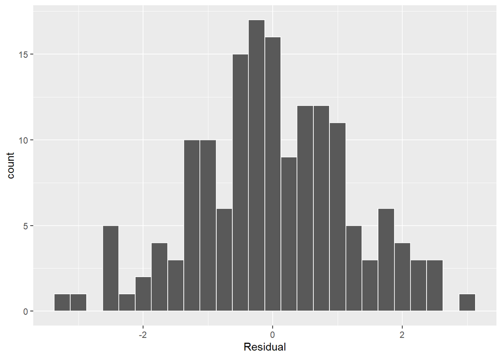

```r
# Plotting the distribution of the residuals to see whether the residuals have a normal distribution
ggplot(assignment_3_dataset, aes(x = residuals)) +
  geom_histogram(binwidth = 0.25, color = "white") +
  labs(x = "Residual")
```

**The histogram shows a fairly normal distribution of the residuals.**

Check the linearity assumption.

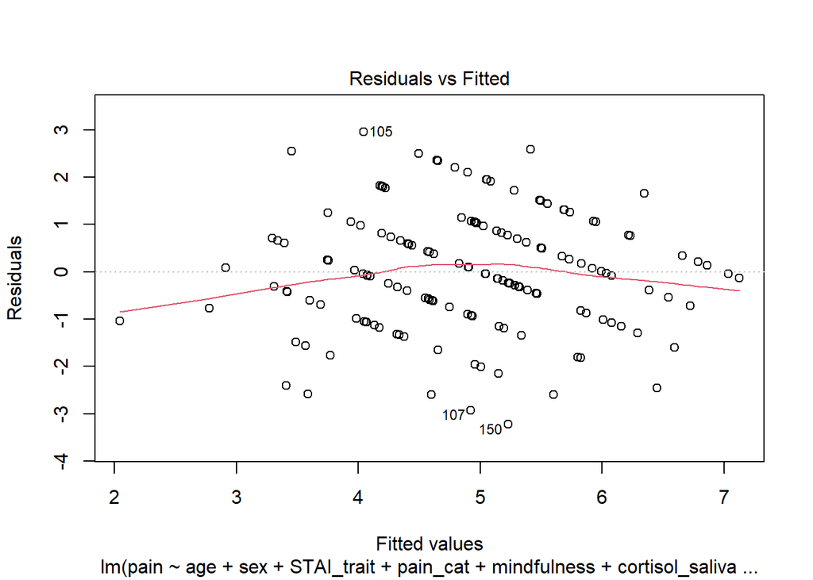

```r
# Checking linearity
plot(complex_model, 1)
```

**Although there is a small curve for the fitted line on the plot, it does not seem to violate the assumption of linearity significantly.**

Check the homoscedasticty assumption (homogeneity of variance).

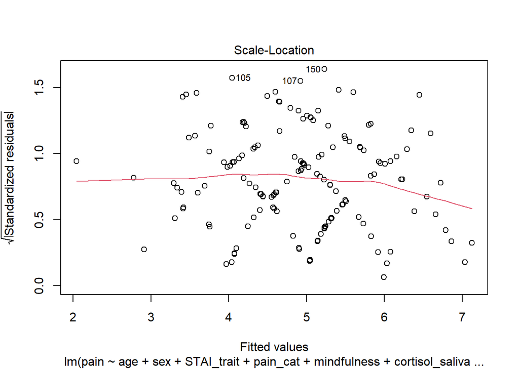

```r
# Checking homoscedasticity
plot(complex_model, 3)
```

**The plot shows that the homoscedasticity assumption is met.**

Check the multicollinearity assumption.

Some info about VIF: https://statisticalhorizons.com/multicollinearity http://blog.minitab.com/blog/understanding-statistics/handling-multicollinearity-in-regression-analysis

```r
# Calculating the VIF for the complex model
vif(complex_model)
```

```
##             age             sex      STAI_trait        pain_cat     mindfulness
##        1.525331        1.144153        2.125108        1.948687        1.527596
## cortisol_saliva  cortisol_serum
##        6.656450        6.093957
```

```r
# Calculating tolerance
1/vif(complex_model)
```

```
##             age             sex      STAI_trait        pain_cat     mindfulness
##       0.6555956       0.8740089       0.4705643       0.5131660       0.6546234
## cortisol_saliva  cortisol_serum
##       0.1502302       0.1640970
```

**The VIF for the cortisol_serum and cortisol_saliva variables was above 3, while tolerance was below 0.2, which indicates a problem with multicollinearity. The solution is dropping the variable cortisol_saliva from the model (because cortisol_serum is the more reliable measure of cortisol, it is better to drop the saliva measure).**